# ivp

```python
import numpy as np
import matplotlib.pyplot as plt
```

```python
%matplotlib notebook
```

## Problem 1

Write a function which implements Euler's method. Test your function on the IVP: $$\begin{align} \begin{split} x' (t)&= x(t) - 2t + 4,\quad 0 \leq t \leq 2, \\ x(0) &= 0, \end{split} \end{align}$$

Use the Euler method to numerically approximate the solution with step sizes $h = 0.2, 0.1$, and $0.05.$ Plot the true solution alongside the three approximations.

```python
def euler(f,x0,t):
    """Numerically approximates the solution to the IVP:

    x'(t) = f(x(t),t)
    x(t0) = x0

    using the Euler method.
    Parameters:
        f (function): The right-hand side of the ODE
        x0 ((m,) ndarray): The initial condition
        t ((n,) ndarray): The array of time values
    Returns:
        ((n,m) ndarray): The approximate solution, where x[i] Ã¢â€°Ë† x(t_i)
    """
    # Calculate Step
    h = t[1] - t[0]
    # Grab dimensions
    m = len(x0)
    n = len(t)
    # Initialize array of approximating values
    x = np.zeros((m, n))
    x[:,0] = x0
    # Run through the algorithm to approximate values
    for i in range(1, n):
        x[:,i] = x0 + h*f(x0, t[i])
        x0 = x[:,i]
    return x
```

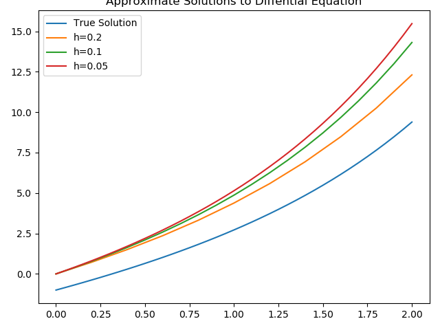

```python
f = lambda x, t: x - 2*t + 4
x0 = np.array([0])
# h = 0.2, 0.1 and 0.05
t1 = np.arange(0, 2.2, 0.2)
t2 = np.arange(0, 2.1, 0.1)
t3 = np.arange(0, 2.05, 0.05)
# Approximate x using the threee h's
x1 = euler(f, x0, t1)
x2 = euler(f, x0, t2)
x3 = euler(f, x0, t3)
# Actual function we are approximating
true_x = lambda x: -2 + 2*x + np.exp(x)
plt.figure(0)
plt.plot(t3, true_x(t3), label="True Solution")
plt.plot(t1, x1[0,:], label="h=0.2")
plt.plot(t2, x2[0,:], label="h=0.1")
plt.plot(t3, x3[0,:], label="h=0.05")
plt.tight_layout()
plt.title("Approximate Solutions to Diffential Equation")
plt.legend()
plt.show()
```

## Problem 2

Write functions that implement the midpoint and fourth-order Runge-Kutta methods. Then, consider again the IVP from Problem 1. Use the Euler, Midpoint, and RK4 methods to approximate the value of the solution for step sizes of $h = 0.2,$ $ 0.1,$ $0.05 $, $0.025,$ and $0.0125.$ Plot the true solution alongside the approximation obtained from each method when $h=0.2$. Then, use `plt.loglog` to create a log-log plot of the relative error $|x(2)-x_n|/{|x(2)|}$ as a function of $h$ for each approximation.

```python
def midpoint(f,x0,t):
    """Numerically approximates the solution to the IVP:

    x'(t) = f(x(t),t)
    x(t0) = x0

    using the midpoint method.
    Parameters:
        f (function): The right-hand side of the ODE
        x0 ((m,) ndarray): The initial condition
        t ((n,) ndarray): The array of time values
    Returns:
        ((n,m) ndarray): The approximate solution, where x[i] Ã¢â€°Ë† x(t_i)
    """
    # Calculate Step
    h = t[1] - t[0]
    # Grab dimensions
    m = len(x0)
    n = len(t)
    # Initialize array of approximating values
    x = np.zeros((m, n))
    x[:,0] = x0
    # Run through the algorithm to approximate values
    for i in range(1, n):
        x_hat = x0 + (h/2)*f(x0, t[i])
        x[:,i] = x0 + h*f(x_hat, t[i] + (h/2))
        x0 = x[:,i]
    return x

def rk4(f,x0,t):
    """Numerically approximates the solution to the IVP:

    x'(t) = f(x(t),t)
    x(t0) = x0

    using a fourth-order Runge-Kutta method.
    Parameters:
        f (function): The right-hand side of the ODE
        x0 ((m,) ndarray): The initial condition
        t ((n,) ndarray): The array of time values
    Returns:
        ((n,m) ndarray): The approximate solution, where x[i] Ã¢â€°Ë† x(t_i)
    """
    # Calculate Step
    h = t[1] - t[0]
    # Grab dimensions
    m = len(x0)
    n = len(t)
    # Initialize array of approximating values
    x = np.zeros((m, n))
    x[:,0] = x0
    # Run through the algorithm to approximate values
    for i in range(1, n):
        k1 = f(x0, t[i-1])
        k2 = f(x0 + (h/2)*k1, t[i-1] + (h/2))
        k3 = f(x0 + (h/2)*k2, t[i-1] + (h/2))
        k4 = f(x0 + h*k3, t[i])
        x[:,i] = x0 + (h/6)*(k1 + 2*k2 + 2*k3 + k4)
        x0 = x[:,i]
    return x
```

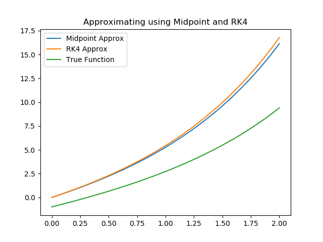

[figure not shown]

```python
x0 = np.array([0])
# Create a new figure
plt.figure(1)
t = np.arange(0, 2.0001, 0.05)
x_approx = midpoint(f, x0, t)
plt.plot(t, x_approx[0,:], label="Midpoint Approx")
x_approx = rk4(f, x0, t)
plt.plot(t, x_approx[0,:], label="RK4 Approx")
plt.plot(time_intervals[2], true_x(time_intervals[2]), label="True Function")
plt.legend()
plt.title("Approximating using Midpoint and RK4")
plt.show()

h = [0.2, 0.1, 0.05, 0.025, 0.0125]
time_intervals = [np.arange(0, 2.00001, i) for i in h]
midpoint_error = []
rk4_error = []
euler_error = []
def compute_error(true_x, approx_x):
    return np.abs(true_x(2) - x_approx[-1, -1]) / np.abs(true_x(2))

for t in time_intervals:
    euler_approx = euler(f, x0, t)
    midpoint_approx = midpoint(f, x0, t)
    midpoint_error.append(compute_error(true_x, midpoint_approx))
    rk4_approx = rk4(f, x0, t)
    rk4_error.append(compute_error(true_x, rk4_approx))

plt.figure(6)
plt.loglog(h, midpoint_error, label="Midpoint Error")
plt.loglog(h, rk4_error, label="RK4 Error")
plt.xlabel("h")
plt.ylabel("Error(h)")
plt.legend()
plt.show()
```

## Problem 3

Use the RK4 method to solve for the simple harmonic oscillator satisfying: $$\begin{align} \begin{split} &{}my'' + ky = 0,\quad 0 \leq t \leq 20, \\ &{}y(0) = 2, \quad y'(0) = -1, \end{split} \end{align}$$

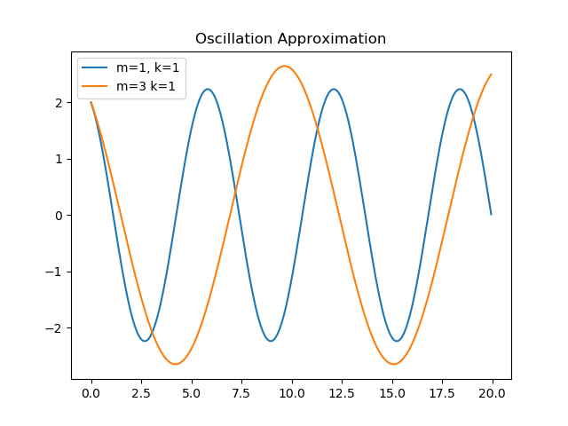

```python
def prob3(x, t, m=1, k=1):
    return np.array([x[1], -(k*x[0])/m])

def wrapper(x, t):
    return prob3(x, t, m=3)

t = np.arange(0.0001, 20.0001, 0.05)
x0 = np.array([2,-1])
approx_vals = rk4(prob3, x0, t)
approx_vals2 = rk4(wrapper, x0, t)
plt.figure(3)
plt.title("Oscillation Approximation")
plt.plot(t, approx_vals[0], label="m=1, k=1")
plt.plot(t, approx_vals2[0], label="m=3 k=1")
plt.legend()
plt.show()
```

## Problem 4

Use the RK4 method to solve for the damped free harmonic oscillator satisfying $$\begin{align*} &{}y'' +\gamma y'+ y = 0, \quad 0 \leq t \leq 20,\\ &{}y(0) = 1, \quad y'(0) = -1. \end{align*}$$ For $\gamma = 1/2,$ and $\gamma = 1$, simultaneously plot your numerical approximations of $y$.

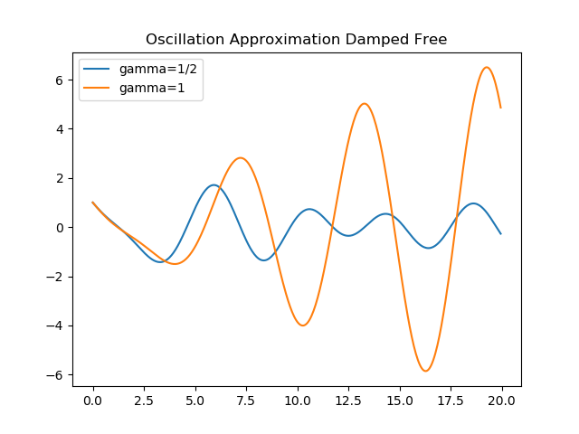

```python
def prob4(x, t, gamma=1/2):
    x1 = x[0]
    x2 = x[1]
    return np.array([x2, -gamma*x2 - x1])
def wrapper(x, t):
    return prob4(x, t, gamma=1)
x0 = np.array([1, -1])
t = np.arange(0.0001, 20.0001, 0.05)
approx_vals = rk4(prob4, x0, t)
approx_vals2 = rk4(wrapper, x0, t)
plt.figure(4)
plt.title("Oscillation Approximation Damped Free")
plt.plot(t, approx_vals[0], label="gamma=1/2")
plt.plot(t, approx_vals2[0], label="gamma=1")
plt.legend()
plt.show()
```

## Problem 5

Use the RK4 method to solve for the damped and forced harmonic oscillator satisfying \begin{align} \begin{split} &{}2y'' + \gamma y' + 2y = 2 \cos (\omega t), \quad 0 \leq t \leq 40,\\ &{}y(0) = 2, \quad y'(0) = -1. \end{split} \label{ivp:damped_forced_oscillator} \end{align} For the following values of $\gamma$ and $\omega,$ plot your numerical approximations of $y(t)$: $(\gamma, \omega) = (0.5, 1.5),$ $(0.1, 1.1),$ and $(0, 1)$.

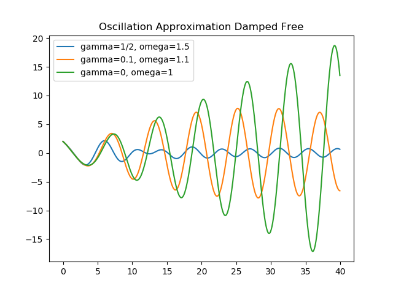

```python
def prob4(x, t, gamma=0.5, omega=1.5):
    x1 = x[0]
    x2 = x[1]
    return np.array([x2, (2*np.cos(omega*t)-gamma*x2-2*x1)/2])
def wrapper(x, t):
    return prob4(x, t, gamma=0.1, omega=1.1)
def wrapper2(x, t):
    return prob4(x, t, gamma=0.0, omega=1.0)
x0 = np.array([2, -1])
t = np.arange(0.0001, 40, 0.05)
approx_vals = rk4(prob4, x0, t)
approx_vals2 = rk4(wrapper, x0, t)
approx_vals3 = rk4(wrapper2, x0, t)
plt.figure(5)
plt.title("Oscillation Approximation Damped Free")
plt.plot(t, approx_vals[0], label="gamma=1/2, omega=1.5")
plt.plot(t, approx_vals2[0], label="gamma=0.1, omega=1.1")
plt.plot(t, approx_vals3[0], label="gamma=0, omega=1")
plt.legend()
plt.show()
```